# Time Series Analysis and Forecasting. Final Assignment

```r
library(xts)
library(forecast)
library(car)
library(ggplot2)
```

### 1. Regression-type modelling and forecasting

**(a) Import the 1st data set to R. Create a ts-object. Keep the last 5 years of data as test data set.**

```r
beerwine <- read.csv('../data/BeerWineUS.csv')
beerwine <- ts(beerwine$MRTSSM4453USN, start = 1992, frequency = 12)
N <- length(beerwine)
beerwine.train <- window(beerwine, end=2012.99)
beerwine.test <- window(beerwine, start=2013)
print(beerwine.test)
```

```
      Jan  Feb  Mar  Apr  May  Jun  Jul  Aug  Sep  Oct  Nov  Dec
2013 3155 3227 3624 3488 3947 3809 4034 4100 3631 3787 4059 5215
2014 3381 3310 3652 3702 4165 4036 4242 4219 3814 4090 4103 5572
2015 3580 3493 3870 3881 4351 4232 4548 4272 4081 4277 4265 5808
2016 3590 3747 4017 4075 4357 4423 4692 4421 4371 4337 4605 5963
2017 3672 3703 4183 4188 4578 4606 4726 4577 4470 4468 4765
```

**(b) Plot the data and choose an appropriate order of time polynomial for modelling. Run a simple regression on the time polynomial and check the autocorrelation of the residuals (also using Durbin-Watson). What can be concluded?**

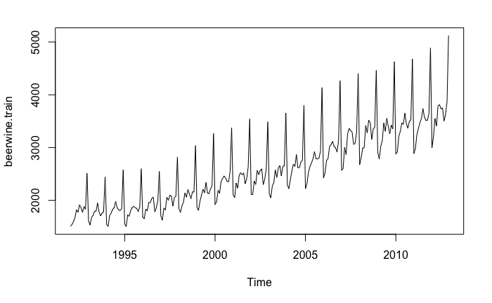

```r
plot(beerwine.train)
```

```
Ignoring unknown aesthetics: ymin, ymax
```

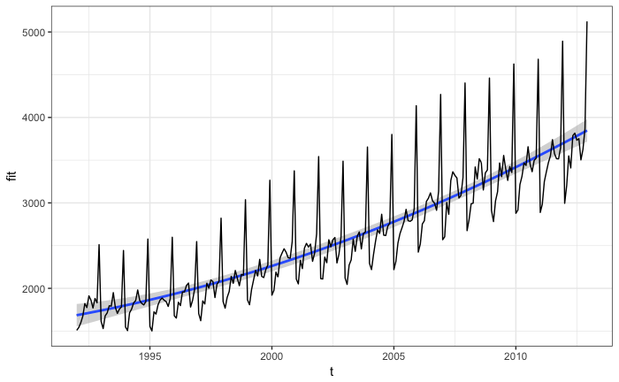

```r
t <- time(beerwine.train)
fit <- lm(beerwine.train ~ I(t^2) + I(t))
prd <- data.frame(t = t)
err <- predict(fit, newdata = prd, se.fit = TRUE)
prd$lci <- err$fit - 1.96 * err$se.fit
prd$fit <- err$fit
prd$uci <- err$fit + 1.96 * err$se.fit
ggplot(prd, aes(x = t, y = fit)) +
  theme_bw() +
  geom_line() +
  geom_smooth(aes(ymin = lci, ymax = uci), stat = "identity") +
  geom_line(data = beerwine.train, aes(x = t, y = beerwine.train))
```

```r
summary(fit)
```

```
Call:
lm(formula = beerwine.train ~ I(t^2) + I(t))

Residuals:
    Min      1Q  Median      3Q     Max
-712.71 -171.46  -39.38   69.19 1277.11

Coefficients:
              Estimate Std. Error t value Pr(>|t|)
(Intercept)  9.522e+06  2.748e+06   3.465 0.000624 ***
I(t^2)       2.426e+00  6.853e-01   3.539 0.000478 ***
I(t)        -9.611e+03  2.745e+03  -3.502 0.000547 ***
---
Signif. codes:  0 '***' 0.001 '**' 0.01 '*' 0.05 '.' 0.1 ' ' 1

Residual standard error: 357.6 on 249 degrees of freedom
Multiple R-squared:  0.7593,    Adjusted R-squared:  0.7574
F-statistic: 392.8 on 2 and 249 DF,  p-value: < 2.2e-16
```

```r
durbinWatsonTest(fit)
```

```
 lag Autocorrelation D-W Statistic p-value
   1     -0.03049885      2.008789   0.912
 Alternative hypothesis: rho != 0
```

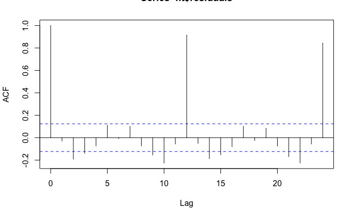

```r
acf(fit$residuals)
```

**(c) Since the time series is rather short to define a dummy for every month, it is rea- sonable to define dummies for longer periods. Use ggmonthplot or ggseasonplot to decide if it is possible to assign dummies to quarters/specific months, etc. Run a corresponding regression and check the residuals as above.**

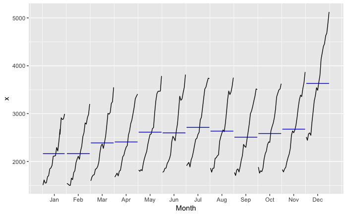

```r
ggmonthplot(beerwine.train)
```

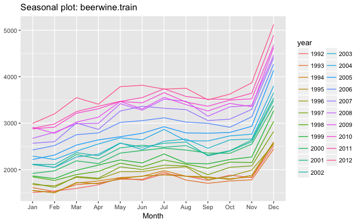

```r
ggseasonplot(beerwine.train)
```

```r
m <- cycle(beerwine.train)
Q1 <- as.numeric(m >= 1 & m <= 7)
Q2 <- as.numeric(m >= 8 & m <= 11)
Q3 <- as.numeric(m == 12)
```

```r
t <- time(beerwine.train)
t1 <- I(t)
t2 <- I(t^2)
beerwine.train.df <- as.data.frame(cbind(beerwine.train, t1, t2, Q1, Q2, Q3))
```

```r
fit <- lm(beerwine.train ~ ., data = beerwine.train.df)
```

```r
summary(fit)
```

```
Call:
lm(formula = beerwine.train ~ ., data = beerwine.train.df)

Residuals:
    Min      1Q  Median      3Q     Max
-564.92 -113.21    1.83  119.62  445.37

Coefficients: (1 not defined because of singularities)
              Estimate Std. Error t value Pr(>|t|)
(Intercept)  9.483e+06  1.424e+06   6.660 1.76e-10 ***
t1          -9.570e+03  1.422e+03  -6.729 1.18e-10 ***
t2           2.415e+00  3.551e-01   6.801 7.78e-11 ***
Q1          -1.127e+03  4.324e+01 -26.068  < 2e-16 ***
Q2          -1.009e+03  4.521e+01 -22.313  < 2e-16 ***
Q3                  NA         NA      NA       NA
---
Signif. codes:  0 '***' 0.001 '**' 0.01 '*' 0.05 '.' 0.1 ' ' 1

Residual standard error: 185.3 on 247 degrees of freedom
Multiple R-squared:  0.9359,    Adjusted R-squared:  0.9349
F-statistic: 901.6 on 4 and 247 DF,  p-value: < 2.2e-16
```

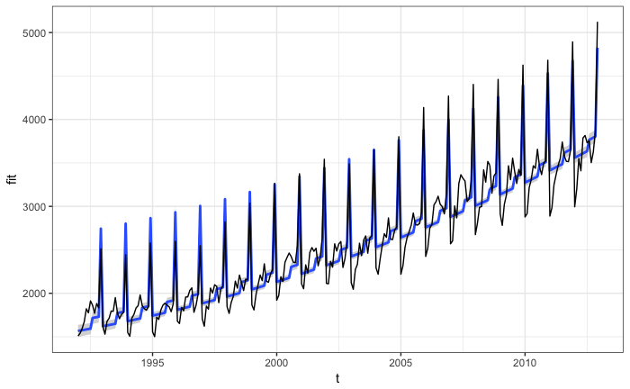

```r
t <- time(beerwine.train)
prd <- data.frame(t = t)
err <- predict(fit, newdata = prd, se.fit = TRUE)
prd$lci <- err$fit - 1.96 * err$se.fit
prd$fit <- err$fit
prd$uci <- err$fit + 1.96 * err$se.fit
ggplot(prd, aes(x = t, y = fit)) +
  theme_bw() +
  geom_line() +
  geom_smooth(aes(ymin = lci, ymax = uci), stat = "identity") +
  geom_line(data = beerwine.train, aes(x = t, y = beerwine.train))
```

```r
durbinWatsonTest(fit)
```

```
 lag Autocorrelation D-W Statistic p-value
   1       0.4238087      1.141438       0
 Alternative hypothesis: rho != 0
```

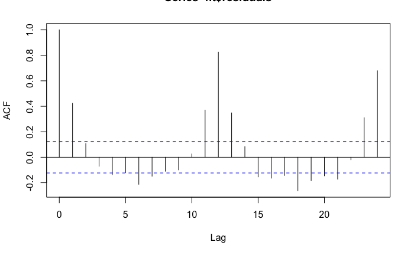

```r
acf(fit$residuals)
```

**(d) With the last model compute the (interval) forecasts for the test data set and visualize the results.**

```r
m <- cycle(beerwine.test)
Q1 <- as.numeric(m >= 1 & m <= 7)
Q2 <- as.numeric(m >= 8 & m <= 11)
Q3 <- as.numeric(m == 12)
```

```r
t <- time(beerwine.test)
t1 <- I(t)
t2 <- I(t^2)
beerwine.test.df <- as.data.frame(cbind(beerwine.test, t1, t2, Q1, Q2, Q3))
```

```r
pred <- as.ts(cbind(beerwine.test, predict(fit, newdata=beerwine.test.df)))
```

```
prediction from a rank-deficient fit may be misleading
```

```r
res = as.ts(cbind(beerwine.train, fit$fitted))
```

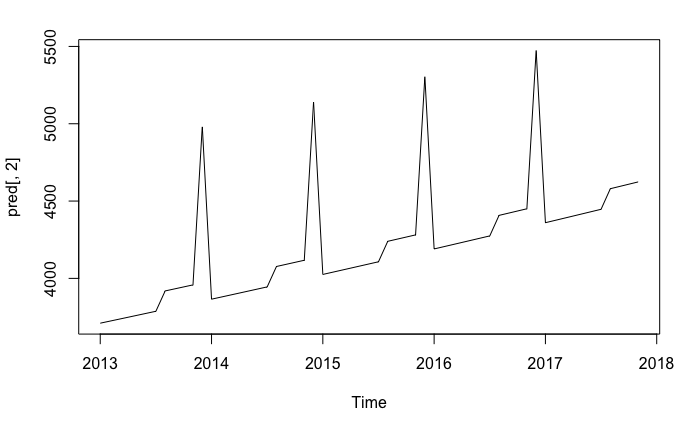

```r
plot(pred[,2])
```

### 2. Time series decomposition

**(a) Try several moving average techniques to extract the trend (ma). Which orders/form of moving averages do provide the best results?**

```r
tau <- 10;
get.maf <- function(width) {
  function(series) {
    rollapply(series, width = width, by = 1, FUN = mean, align = "right")
  }
}
```

```r
maf3 <- get.maf(3)
maf5 <- get.maf(5)
maf7 <- get.maf(7)
```

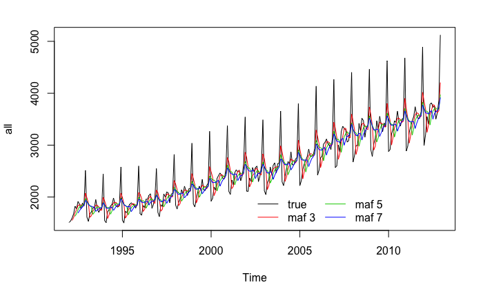

```r
s <- beerwine.train
all.forec <- cbind(maf3(s), maf5(s), maf7(s))
all <- cbind(s, all.forec);
plot.ts(all, plot.type="single", col=c(1:6,1:5))
model.names <- c("true", "maf 3", "maf 5", "maf 7")
legend(x = "bottomright", legend=model.names, ncol=3, bty="n", col=c(1:6,1:5), lty=c(rep(1,6),rep(2,6)))
```

**(b) Apply the loess regression for trend extraction.**

We apply R’s stl() function (“seasonal and trend decomposition using Loess”) to decompose beerwine data

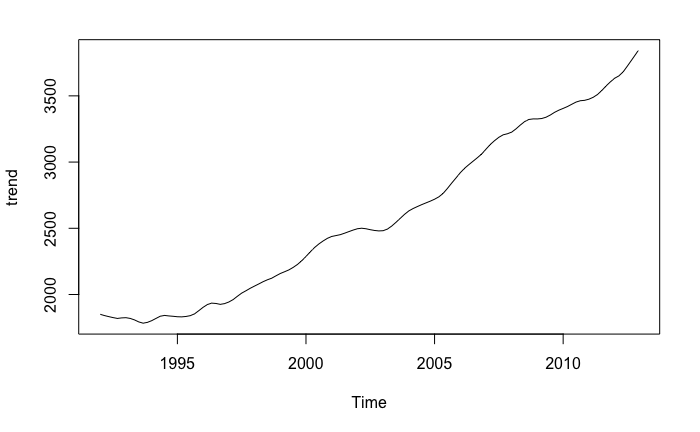

```r
decomposed <- stl(beerwine.train, s.window="periodic")
trend <- decomposed$time.series[,2]
plot(trend)
```

**(c) For one of the above computed trends compute the seasonal and the irregular components. Visualize the decomposition.**

```r
seasonal <- decomposed$time.series[,1]
irregular <- decomposed$time.series[,3]
```

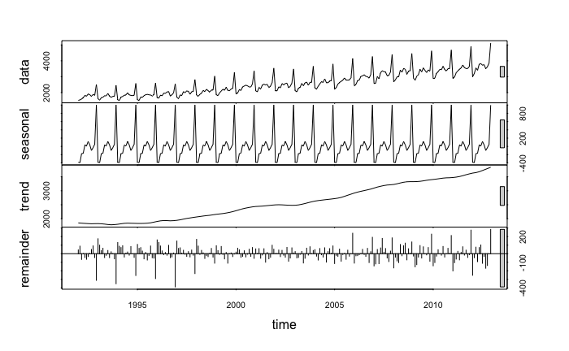

```r
plot(decomposed)
```

**(d) Check the ACF of the irregular component. Is there anything left in the time series?**

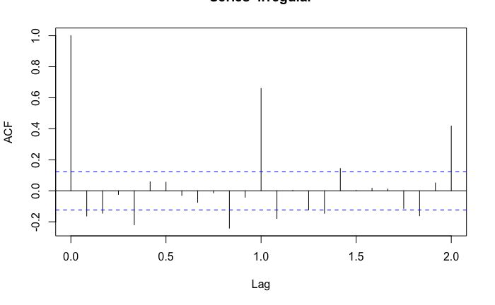

```r
acf(irregular)
```

Yes, there are big spikes at lags 1 and 2. So the current value still depends consistently on the value of the same month in a previous year.

### 3. Simple forecasting and forecasting with exponential smoothing

**(a) Compute simple one-step-ahead forecasts for the test data set using naıve, absolute trend and relative trend methods. Compute the corresponding losses.**

```r
tau <- length(beerwine.test) - 1
seas.naive <- function(series) {
  sapply(tau:1, function(x) snaive(head(series, -x), 1)$mean)
}
abs.trend <- function(series) {
  n <- length(series)
  2 * series[(n - tau):(n - 1)] - series[(n - tau - 1):(n - 2)]
}
rel.trend <- function(series) {
  n <- length(series)
  series[(n - tau):(n - 1)] ^ 2 / series[(n - tau - 1):(n - 2)]
}
```

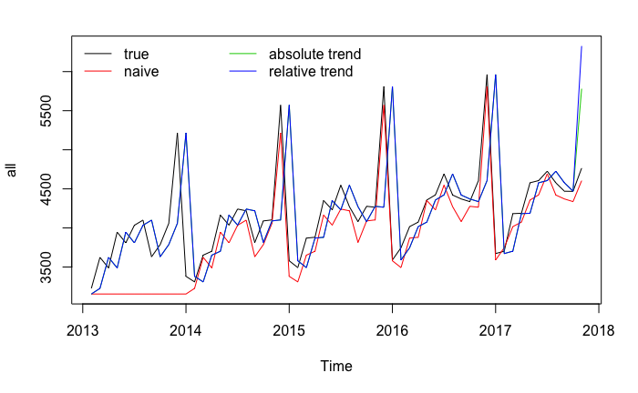

```r
s <- beerwine.test
all.forec <- cbind(seas.naive(s), abs.trend(s), rel.trend(s))
all <- cbind(tail(s, tau), all.forec)
plot.ts(all, plot.type="single", col=c(1:6,1:5))
model.names <- c("true", "naive", "absolute trend", "relative trend")
legend(x = "topleft", legend=model.names, ncol=3, bty="n", col=c(1:6,1:5), lty=c(rep(1,6),rep(2,6)))
```

```r
loss.functions <- function(x.hat, x) {
  c(mean((x-x.hat)^2), mean(abs(x-x.hat)), mean(abs( (x-x.hat)/x )) )
}
```

```r
apply(all.forec, 2, function(x) loss.functions(x, tail(beerwine.test, tau)))
```

```
             [,1]         [,2]         [,3]
[1,] 1.794745e+05 5.025667e+05 5.268583e+05
[2,] 2.780517e+02 4.196034e+02 4.290246e+02
[3,] 6.637267e-02 1.009583e-01 1.029354e-01
```